# Hoja3_MD

Alejandra Guzman, Mariana David, Jorge Caballeros

2023-03-05

# 1. Descargar los datos y cargar los datos

Guardaremos train en un objeto llamado data

```r
data <- read.csv('./train.csv') # nolint
```

# 2. Analisis exploratorio

## Variables numericas

Presentamos las variables de nuestra data que pertenecen al ambito numérico

```r
vars_numericas <- sapply(data, is.numeric)
print(vars_numericas)
```

```
##            Id    MSSubClass      MSZoning   LotFrontage       LotArea
##          TRUE          TRUE         FALSE          TRUE          TRUE
##        Street         Alley      LotShape   LandContour     Utilities
##         FALSE         FALSE         FALSE         FALSE         FALSE
##     LotConfig     LandSlope  Neighborhood    Condition1    Condition2
##         FALSE         FALSE         FALSE         FALSE         FALSE
##      BldgType    HouseStyle   OverallQual   OverallCond     YearBuilt
##         FALSE         FALSE          TRUE          TRUE          TRUE
##  YearRemodAdd     RoofStyle      RoofMatl   Exterior1st   Exterior2nd
##          TRUE         FALSE         FALSE         FALSE         FALSE
##    MasVnrType    MasVnrArea     ExterQual     ExterCond    Foundation
##         FALSE          TRUE         FALSE         FALSE         FALSE
##      BsmtQual      BsmtCond  BsmtExposure  BsmtFinType1    BsmtFinSF1
##         FALSE         FALSE         FALSE         FALSE          TRUE
##  BsmtFinType2    BsmtFinSF2     BsmtUnfSF   TotalBsmtSF       Heating
##         FALSE          TRUE          TRUE          TRUE         FALSE
##     HeatingQC    CentralAir    Electrical     X1stFlrSF     X2ndFlrSF
##         FALSE         FALSE         FALSE          TRUE          TRUE
##  LowQualFinSF     GrLivArea  BsmtFullBath  BsmtHalfBath      FullBath
##          TRUE          TRUE          TRUE          TRUE          TRUE
##      HalfBath  BedroomAbvGr  KitchenAbvGr   KitchenQual  TotRmsAbvGrd
##          TRUE          TRUE          TRUE         FALSE          TRUE
##    Functional    Fireplaces   FireplaceQu    GarageType   GarageYrBlt
##         FALSE          TRUE         FALSE         FALSE          TRUE
##  GarageFinish    GarageCars    GarageArea    GarageQual    GarageCond
##         FALSE          TRUE          TRUE         FALSE         FALSE
##    PavedDrive    WoodDeckSF   OpenPorchSF EnclosedPorch    X3SsnPorch
##         FALSE          TRUE          TRUE          TRUE          TRUE
##   ScreenPorch      PoolArea        PoolQC         Fence   MiscFeature
##          TRUE          TRUE         FALSE         FALSE         FALSE
##       MiscVal        MoSold        YrSold      SaleType SaleCondition
##          TRUE          TRUE          TRUE         FALSE         FALSE
##     SalePrice
##          TRUE
```

Realizamos un analisis de data frame con los datos sacados con anterioridad para poder analizarlos

```r
numeric_data <- select_if(data, is.numeric)
numeric_data <- numeric_data[complete.cases(numeric_data), ]
```

Normalizamos el paso anterior

```r
numeric_data <- scale(na.omit(numeric_data))
```

## Analisis de Hopkins

Realizamos un análisis de Hopkings, en donde si este sale superior a 0.5 que es el valor esperado, entonces podemos generar divisiones o agrupamientos en la data.

```r
set.seed(123)
hopkins(numeric_data)
```

```
## [1] 1
```

```r
data_dist <- dist(numeric_data)
```

Al ver que el valor de Hopkins en superiro a 0.5, podemos hacer divisiones en la data

## Metodo grafico la VAT

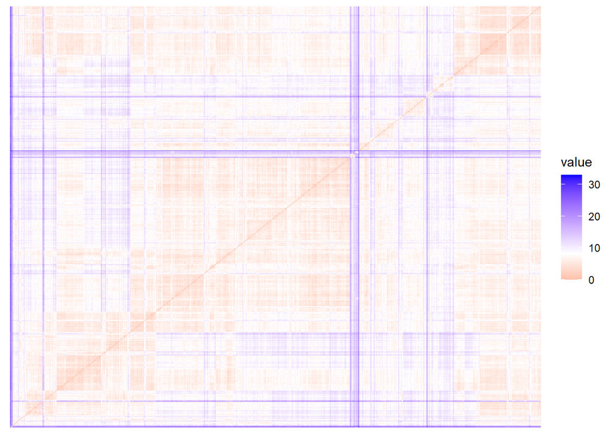

```r
knitr::opts_chunk$set(fig.width = 20, fig.height = 10)
fviz_dist(data_dist, show_labels = FALSE)
```

Como se puede observar si existen patrones en la grafica, tiene cualidades compartidas y por ende agrupales. También confirma nuevamente el resultado Hopkins.

## Analisis de Clusters

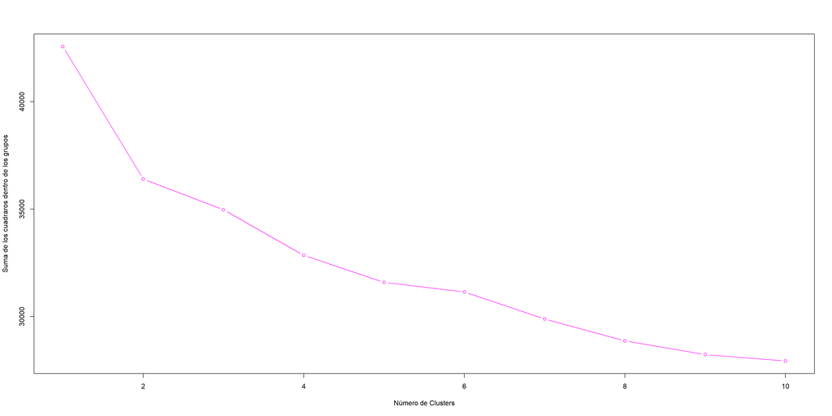

```r
wss=0
for (i in 1:10)
  wss[i] <- sum(kmeans(numeric_data, centers = i)$withinss)
plot(1:10, wss, type="b", xlab="Número de Clusters",
  ylab="Suma de los cuadraros dentro de los grupos",
   col = "magenta")
```

## Análisis de silueta / Clusters

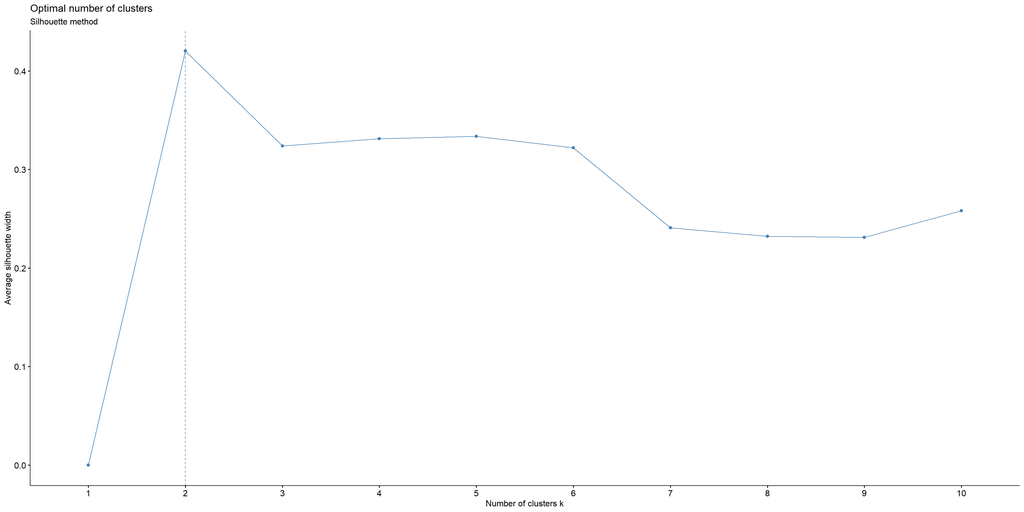

```r
fviz_nbclust(numeric_data[, 1:4], kmeans, method = "silhouette") +
labs(subtitle = "Silhouette method")
```

```r
 #Clustering jerarquico
hclust_res <- hclust(dist(numeric_data), method = "complete")
clusters_hclust <- cutree(hclust_res, k = 5)
```

# 3. Analisis de grupo

## Analizar el petal de los datos

```r
# Cargando el conjunto de datos Iris
data(iris)

# Creando un data frame con los datos y la variable objetivo
datos <- data.frame(iris$Sepal.Length, iris$Sepal.Width, iris$Petal.Length, iris$Petal.Width, iris$Species) # nolint

# Renombrando las columnas
colnames(datos) <- c("Sepal.length", "Sepal.width", "Petal.length", "Petal.width", "Species") # nolint
```

## Graficar las variables Petal.Length y Petal.Width

```r
# Verificar si hay valores no finitos en x
is.finite(datos$Petal.length)
```

```
##   [1] TRUE TRUE TRUE TRUE TRUE TRUE TRUE TRUE TRUE TRUE TRUE TRUE TRUE TRUE TRUE
##  [16] TRUE TRUE TRUE TRUE TRUE TRUE TRUE TRUE TRUE TRUE TRUE TRUE TRUE TRUE TRUE
##  [31] TRUE TRUE TRUE TRUE TRUE TRUE TRUE TRUE TRUE TRUE TRUE TRUE TRUE TRUE TRUE
##  [46] TRUE TRUE TRUE TRUE TRUE TRUE TRUE TRUE TRUE TRUE TRUE TRUE TRUE TRUE TRUE
##  [61] TRUE TRUE TRUE TRUE TRUE TRUE TRUE TRUE TRUE TRUE TRUE TRUE TRUE TRUE TRUE
##  [76] TRUE TRUE TRUE TRUE TRUE TRUE TRUE TRUE TRUE TRUE TRUE TRUE TRUE TRUE TRUE
##  [91] TRUE TRUE TRUE TRUE TRUE TRUE TRUE TRUE TRUE TRUE TRUE TRUE TRUE TRUE TRUE
## [106] TRUE TRUE TRUE TRUE TRUE TRUE TRUE TRUE TRUE TRUE TRUE TRUE TRUE TRUE TRUE
## [121] TRUE TRUE TRUE TRUE TRUE TRUE TRUE TRUE TRUE TRUE TRUE TRUE TRUE TRUE TRUE
## [136] TRUE TRUE TRUE TRUE TRUE TRUE TRUE TRUE TRUE TRUE TRUE TRUE TRUE TRUE TRUE
```

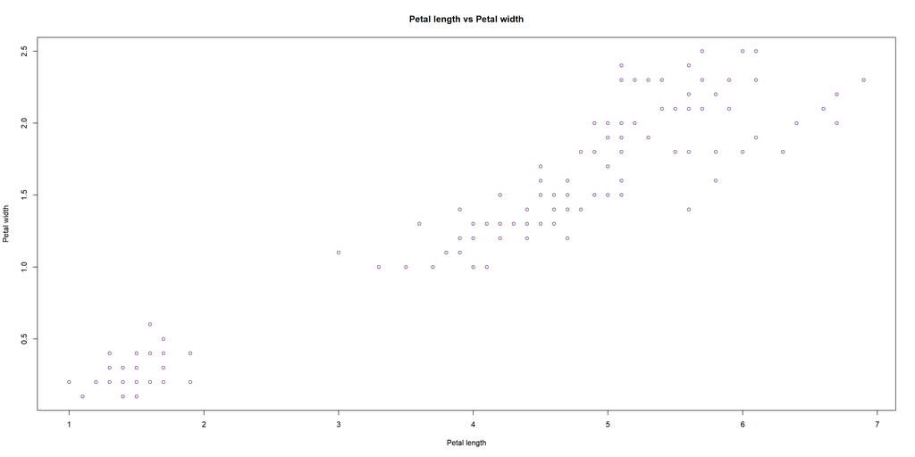

```r
# Eliminar filas con valores perdidos de los datos
datos_sin_na <- na.omit(datos)

# Graficar los datos sin valores perdidos en x
plot(datos_sin_na$Petal.length, datos_sin_na$Petal.width,
     xlab = "Petal length",
     ylab = "Petal width",
     main = "Petal length vs Petal width", col = "darkorchid4")
```

# 4.Division del set: Entrenamiento y prueba

```r
# separar las variables de respuesta
Specie <- datos$Specie # nolint
Petal.length <- datos$Petal.length # nolint
# eliminar las variables de respuesta del conjunto de datos original
datos <- datos[, !(names(datos) %in% c("Specie", "Petal.length"))]
# dividir los datos en conjuntos de entrenamiento y prueba
set.seed(123)  # para hacer los resultados reproducibles
library(caTools)
train_size <- 0.7
split <- sample.split(1:nrow(datos), SplitRatio = train_size) # nolint
X_train <- datos[split, ] # nolint
X_test <- datos[!split, ] # nolint
y_train <- Petal.length[split]
y_test <- Petal.length[!split]
```

Teniendo en cuenta que se usaremos 70% de entrenamiento y 30% de los datos en forma prueba

## Haciendo regresion lineal

```r
# convertir vectores a matrices
p_length <- matrix(y_train, ncol = 1)
p_length_t <- matrix(y_test, ncol = 1)
p_width <- matrix(X_train$Petal.width, ncol = 1)
p_width_t <- matrix(X_test$Petal.width, ncol = 1)
# ajustar el modelo de regresión lineal
lm <- lm(p_length ~ p_width)
# predecir valores de longitud de pétalo para los datos de prueba
p_length_pred <- predict(lm, newdata = list(p_width = p_width_t))
```

## Haciendo la ecuacion

```r
# y = mx + c # nolint
m <- coef(lm)[2]
c <- coef(lm)[1]
label <- sprintf("p_length = %0.4f*p_width %+0.4f", m, c)
cat(label)
```

```
## p_length = 2.2132*p_width +1.0975
```

## Grafica de datos y predicciones

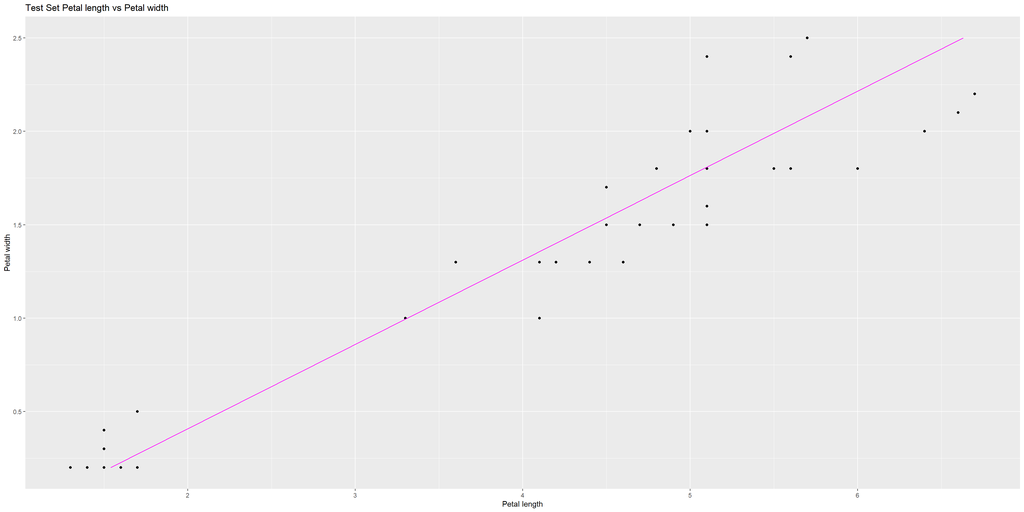

```r
# crear un data frame con los datos de prueba y las predicciones
df <- data.frame(Petal.length = p_length_t[,1], Petal.width = p_width_t[,1], Predicted.Petal.length = p_length_pred)
# graficar los datos y las predicciones
ggplot(df, aes(x = Petal.length, y = Petal.width)) +
  geom_point() +
  geom_line(aes(x = Predicted.Petal.length, y = Petal.width), color = "magenta") +
  labs(x = "Petal length", y = "Petal width", title = "Test Set Petal length vs Petal width")
```

## Analizadno R²

```r
# Calcular el error cuadrático medio y el coeficiente de determinación
mse <- mse(p_length_t, p_length_pred)
rsq <- summary(lm(p_length_t ~ p_length_pred))$r.squared
# Imprimir los resultados
cat("Error medio cuadrado: ", format(mse, digits = 2), "\n")
```

```
## Error medio cuadrado:  0.25
```

```r
cat("R-cuadrado: ", format(rsq, digits = 2), "\n")
```

```
## R-cuadrado:  0.92
```

Este análisis hace referencia a que hay 90% de la variabilidad de los datos; signigicando que es un resultado bueno.

## Analisis de los residuales

```r
residuales <- p_length_t - p_length_pred
length(residuales)
```

```
## [1] 45
```

A continuacion se genera un grafico para los residuales

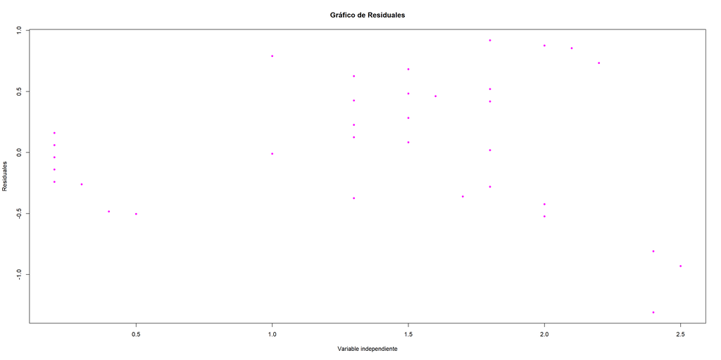

```r
plot(p_width_t, residuales, pch = 20, col = "magenta",
     main = "Gráfico de Residuales",
     xlab = "Variable independiente",
     ylab = "Residuales")
```

Como podemos obersvar según el gráfico de los puntos residuale se puede observar que parecen estar distribuidos de una manera bastante aleatoria pero con un tipo de rango rodeando al cero

Ahora por medio de una grafica de campana analizaremos los residuales y tambien por medio de caja y bigotes

```r
# residuales
residuales <- p_length_t - p_length_pred
length(residuales)
```

```
## [1] 45
```

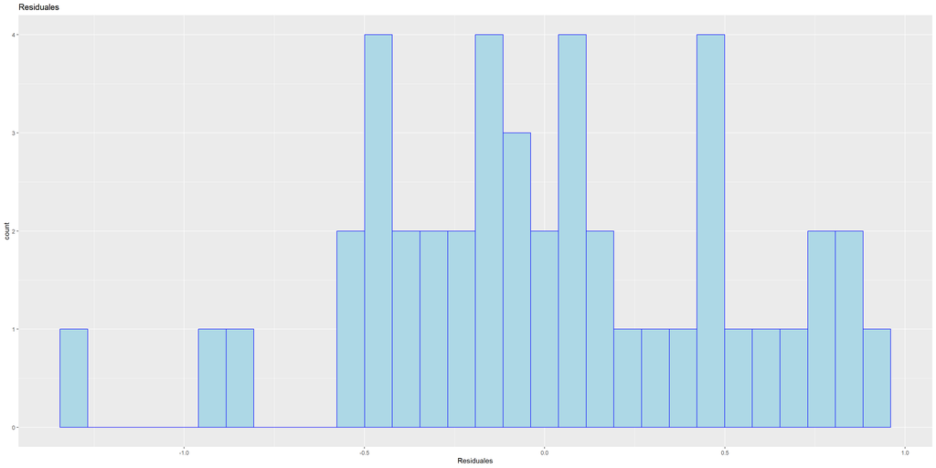

```r
# distribución de residuales
library(ggplot2)
ggplot(data.frame(residuales), aes(x = residuales)) +
  geom_histogram(bins = 30, color = "blue", fill = "lightblue") +
  ggtitle("Residuales") +
  xlab("Residuales")
```

A continuacion se presenta el analissi por medio del método grafico de caja y bigotes

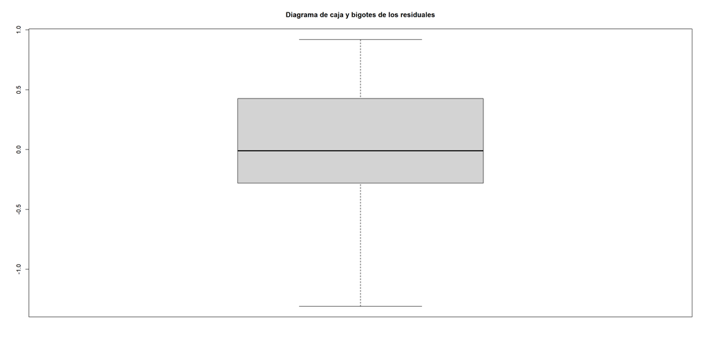

```r
# diagrama de caja y bigoes  de residuales
boxplot(residuales, main = "Diagrama de caja y bigotes de los residuales")
```

Como podemos ver los residuos siguen una distribución normal. Sine mebargo se aplicara un procedimiento adicional para garantizar si estos son mayores al valor normal 0.5

```r
shapiro.test(residuales)
```

```
##
##  Shapiro-Wilk normality test
##
## data:  residuales
## W = 0.9779, p-value = 0.5372
```

Como vemos al aplicar shapiro vemos que el valor de p es mayor a 0.05, por ende se sostiene que el analisis de los residuos siguen una distribucion normal.